#### **Федеральное государственное автономное образовательное учреждение высшего**

#### **профессионального образования**

### **Национальный исследовательский университет**

### **“Высшая школа экономики”**

#### **Факультет экономических наук**

#### **Образовательная программа Экономика и статистика**

## **Компьютерная работа 1**

*Студентов группы БСТ213*

Курченко М. А., Леготкина Е. Р., Куклина Э. О.,

Яргина К. В., Киренкина В. Ю., Борисова П. П.

Москва, 2023 г.

### **Постановка задачи**

Для выполнения работы нами был выбран датасет c [Kaggle](https://www.kaggle.com/datasets/hellbuoy/car-price-prediction), содержащий информацию о технических характеристиках автомобилей на американском рынке. Массив данных насчитывает *более двухсот* **моделей авто разных классов** и **не содержит** пропущенных значений, что **обеспечивает репрезентативность выборки**.  
Ввиду ряда ограничений, обусловленных спецификой задания, из датасета были полностью исключены как категориальные признаки, так и те, что принимают дискретные значения.  
Продемонстрируем то, как выглядят уже подготовленные нами данные для дальнейшего анализа:

|  | wheelbase | carlength | carwidth | carheight | curbweight | enginesize | horsepower | peakrpm | citympg | highwaympg | price |
| --- | --- | --- | --- | --- | --- | --- | --- | --- | --- | --- | --- |
| 1 | 88.6 | 168.8 | 64.1 | 48.8 | 2548 | 130 | 111 | 5000 | 21 | 27 | 13495.00 |
| 2 | 88.6 | 168.8 | 64.1 | 48.8 | 2548 | 130 | 111 | 5000 | 21 | 27 | 16500.00 |
| 3 | 94.5 | 171.2 | 65.5 | 52.4 | 2823 | 152 | 154 | 5000 | 19 | 26 | 16500.00 |
| 4 | 99.8 | 176.6 | 66.2 | 54.3 | 2337 | 109 | 102 | 5500 | 24 | 30 | 13950.00 |
| 5 | 99.4 | 176.6 | 66.4 | 54.3 | 2824 | 136 | 115 | 5500 | 18 | 22 | 17450.00 |
| 6 | 99.8 | 177.3 | 66.3 | 53.1 | 2507 | 136 | 110 | 5500 | 19 | 25 | 15250.00 |
| 7 | 105.8 | 192.7 | 71.4 | 55.7 | 2844 | 136 | 110 | 5500 | 19 | 25 | 17710.00 |
| 8 | 105.8 | 192.7 | 71.4 | 55.7 | 2954 | 136 | 110 | 5500 | 19 | 25 | 18920.00 |
| 9 | 105.8 | 192.7 | 71.4 | 55.9 | 3086 | 131 | 140 | 5500 | 17 | 20 | 23875.00 |
| 10 | 99.5 | 178.2 | 67.9 | 52.0 | 3053 | 131 | 160 | 5500 | 16 | 22 | 17859.17 |

[output cut: 195 more lines]

Описание данных

| Переменная | Описание переменной |
| --- | --- |
| **Габариты авто** |  |
| carlength | длина авто (в футах) |
| carwidth | ширина авто (в футах) |
| carheight | высота авто (в футах) |
| **Двигатель** |  |
| enginesize | объем двигателя (в кубических дюймах) |
| horsepower | лошадиные силы (в киловаттах) |
| peakrpm | кол-во оборотов, на которых достигается максимальная мощность двигателя |
| **Расход топлива** |  |
| citympg | миль на галлон топлива, потребляемого при движении по городу |
| highwaympg | миль на галлон топлива потребляемого при движении по шоссе |
| **Прочее** |  |
| wheelbase | расстояние между передними и задними колесами автомобиля (в футах) |
| curbweight | вес (в фунтах) |
| **Зависимая переменная** |  |
| price | цена авто (в $) |

В ходе исследования мы планируем выяснить, как влияют отобранные факторы на стоимость машины. Сформулируем ряд гипотез, которые приблизят нас к ответу на поставленный вопрос:

- Зависимая переменная “цена авто” имеет нормальное распределение
- Группа факторов “Габариты машины” оказывает наибольшее влияние на зависимую переменную (цена авто)
- Группа факторов “Прочее” имеет линейную зависимость с переменной “цена авто”

### **Основные характеристики (сarlength, carwidth, carheight)**

Приступим к предварительному анализу переменных. Начнем с признаков, отнесенных в категорию “*Габариты авто*”:

*Характеристики положения СВ:*

```r
pander(paste('Среднее: ', round(mean(df$carlength), 3)))
```

Среднее: 174.049

```r
pander(paste('Медиана: ', median(df$carlength)))
```

Медиана: 173.2

```r
pander(paste('Мода: ', Mode(df$carlength)))
```

Мода: 157.3

Как можно заметить, среднее и медиана переменной **`carlength`** оказались практически равны, в отличии от модального значения, которое сильно от них отличается. Так, можем предположить, что данный признак не подчиняется нормальному закону распределения.

*Характеристики разброса СВ:*

```r
ch_var1 <- data.frame('Статистика' =
                       c('Min', 'Max', 'Размах: R',
                         'Дисперсия', 'Std dev',
                         'IQR', 'Coef var, %'),
                     'Значение' = c(range(df$carlength)[1],
                                    range(df$carlength)[2],
                                    round(range(df$carlength)[2] - range(df$carlength)[1], 3),
                     round(var(df$carlength), 3),
                     round(sd(df$carlength), 3),
                     IQR(df$carlength),
                     round(CoefVar(df$carlength)*100, 2)))

pander(ch_var1)
```

| Статистика | Значение |
| --- | --- |
| Min | 141.1 |
| Max | 208.1 |
| Размах: R | 67 |
| Дисперсия | 152.2 |
| Std dev | 12.34 |
| IQR | 16.8 |
| Coef var, % | 7.09 |

Значение коэффициента вариации **не превышает 33%**, что говорит нам об однородности переменной **`carlength`**.

*Ранговые характеристики СВ:*

```r
pander(summary(df$carlength))
```

| Min. | 1st Qu. | Median | Mean | 3rd Qu. | Max. |
| --- | --- | --- | --- | --- | --- |
| 141.1 | 166.3 | 173.2 | 174 | 183.1 | 208.1 |

```r
pander(quantile(df$carlength))
```

| 0% | 25% | 50% | 75% | 100% |
| --- | --- | --- | --- | --- |
| 141.1 | 166.3 | 173.2 | 183.1 | 208.1 |

Так, для случайной величины **`carlength`** мы получили: *Q1* = 166,3 и *Q3* = 183,1 – границы, ниже (выше) которых лежат по 25% процентов выборки.

```r
pander(quantile(df$carlength, probs = seq(0, 1, 0.1)))
```

| 0% | 10% | 20% | 30% | 40% | 50% | 60% | 70% | 80% | 90% | 100% |
| --- | --- | --- | --- | --- | --- | --- | --- | --- | --- | --- |
| 141.1 | 157.3 | 165.3 | 168.7 | 171.5 | 173.2 | 175.6 | 177.8 | 186.6 | 188.8 | 208.1 |

Для данной СВ мы также нашли *децили*: 30% значений выборки меньше 168,7, а медиана равна 173,2, то есть половина значений выборки лежат левее (правее) отметки в 173,2. Минимум и максимум соответственно равны 141,1 и 208,1.

Теперь проделаем те же шаги для переменной **`carwidth`**.

*Характеристики положения СВ:*

```r
pander(paste('Среднее: ', round(mean(df$carwidth), 3)))
```

Среднее: 65.908

```r
pander(paste('Медиана: ', median(df$carwidth)))
```

Медиана: 65.5

```r
pander(paste('Мода: ', Mode(df$carwidth)))
```

Мода: 63.8

Полученные значения среднего, медианы и моды очень близки между собой. Это позволяет нам сделать предположение о том, что распределение данной СВ может подчинятся *нормальному закону распределения*.

*Характеристики разброса СВ:*

```r
ch_var2 <- data.frame('Статистика' =
                       c('Min', 'Max', 'Размах: R',
                         'Дисперсия', 'Std dev',
                         'IQR', 'Coef var, %'),
                     'Значение' = c(range(df$carwidth)[1],
                                    range(df$carwidth)[2],
                                    round(range(df$carwidth)[2] - range(df$carwidth)[1], 3),
                     round(var(df$carwidth), 3),
                     round(sd(df$carwidth), 3),
                     IQR(df$carwidth),
                     round(CoefVar(df$carwidth)*100, 2)))

pander(ch_var2)
```

| Статистика | Значение |
| --- | --- |
| Min | 60.3 |
| Max | 72.3 |
| Размах: R | 12 |
| Дисперсия | 4.602 |
| Std dev | 2.145 |
| IQR | 2.8 |
| Coef var, % | 3.25 |

Значение коэффициента вариации не превышает 33%. Это говорит нам об однородности переменной **`carwidth`**.

*Ранговые характеристики СВ:*

```r
pander(summary(df$carwidth))
```

| Min. | 1st Qu. | Median | Mean | 3rd Qu. | Max. |
| --- | --- | --- | --- | --- | --- |
| 60.3 | 64.1 | 65.5 | 65.91 | 66.9 | 72.3 |

```r
pander(quantile(df$carwidth))
```

| 0% | 25% | 50% | 75% | 100% |
| --- | --- | --- | --- | --- |
| 60.3 | 64.1 | 65.5 | 66.9 | 72.3 |

Для случайной величины **`carwidth`** мы получили: *Q1* = 64,1 и *Q3* = 66,9 – границы, ниже (выше) которых лежат по 25% процентов всей выборки.

```r
pander(quantile(df$carwidth, probs = seq(0, 1, 0.1)))
```

| 0% | 10% | 20% | 30% | 40% | 50% | 60% | 70% | 80% | 90% | 100% |
| --- | --- | --- | --- | --- | --- | --- | --- | --- | --- | --- |
| 60.3 | 63.8 | 63.9 | 64.4 | 65.2 | 65.5 | 66.3 | 66.5 | 67.3 | 68.64 | 72.3 |

Аналогичные выводы можно сделать и по децилям. Например, 10% выборки принимают значения меньше 63,8, а 90% – соответственно больше 63,8. Можно заметить, что разница между медианой и минимальным значением несколько меньше, чем разница между максимальным значением и медианой, что может свидетельствовать о незначительной правосторонней асимметрии.

Проведем такой же анализ для признака **`carheight`**.

*Характеристики положения СВ:*

```r
pander(paste('Среднее: ', round(mean(df$carheight), 3)))
```

Среднее: 53.725

```r
pander(paste('Медиана: ', median(df$carheight)))
```

Медиана: 54.1

```r
pander(paste('Мода: ', Mode(df$carheight)))
```

Мода: 50.8

Среди полученных значений немного выбивается мода, что ставит под сомнение гипотезу о нормальном распределении переменной.

*Характеристики разброса СВ:*

```r
ch_var3 <- data.frame('Статистика' =
                       c('Min', 'Max', 'Размах: R',
                         'Дисперсия', 'Std dev',
                         'IQR', 'Coef var, %'),
                     'Значение' = c(range(df$carheight)[1],
                                    range(df$carheight)[2],
                                    round(range(df$carheight)[2] - range(df$carheight)[1], 3),
                     round(var(df$carheight), 3),
                     round(sd(df$carheight), 3),
                     IQR(df$carheight),
                     round(CoefVar(df$carheight)*100, 2)))

pander(ch_var3)
```

| Статистика | Значение |
| --- | --- |
| Min | 47.8 |
| Max | 59.8 |
| Размах: R | 12 |
| Дисперсия | 5.971 |
| Std dev | 2.444 |
| IQR | 3.5 |
| Coef var, % | 4.55 |

Значение коэффициента вариации не превышает 33%. Это говорит нам об однородности переменной **`carheigth`**.

*Ранговые характеристики СВ:*

```r
pander(summary(df$carheight))
```

| Min. | 1st Qu. | Median | Mean | 3rd Qu. | Max. |
| --- | --- | --- | --- | --- | --- |
| 47.8 | 52 | 54.1 | 53.72 | 55.5 | 59.8 |

```r
pander(quantile(df$carheight))
```

| 0% | 25% | 50% | 75% | 100% |
| --- | --- | --- | --- | --- |
| 47.8 | 52 | 54.1 | 55.5 | 59.8 |

Для случайной величины **`carheight`** мы получили: Q1 = 52 и *Q3* = 55,5. Следовательно, 25% выборки принимает значения меньше 52 а еще четверть выборки – больше 55,5.

```r
pander(quantile(df$carheight, probs = seq(0, 1, 0.1)))
```

| 0% | 10% | 20% | 30% | 40% | 50% | 60% | 70% | 80% | 90% | 100% |
| --- | --- | --- | --- | --- | --- | --- | --- | --- | --- | --- |
| 47.8 | 50.6 | 51.4 | 52.42 | 53 | 54.1 | 54.5 | 55.1 | 55.7 | 56.62 | 59.8 |

Для этой случайной величины мы также нашли децили. Медиана равна 54,1, то есть ровно половина значений выборки принимают больше (меньше) 54,1.

### **Диагностика выбросов (сarlength, carwidth, carheight)**

*Расчет межквартильной разницы СВ:*

```r
pander(paste('Межквартильный размах: IQR = Q3 - Q1 = ', round(IQR(df$carlength), 3)))
```

Межквартильный размах: IQR = Q3 - Q1 = 16.8

*Найдем значения, выходящие за пределы 1,5IQR:*

```r
carlength_sorted <- sort(df$carlength)
out_of_1.5IQR1 <- boxplot.stats(df$carlength, coef = 1.5)$out
out_of_1.5IQR1
```

```
## [1] 141.1
```

Получаем один выброс – 141,1.

Определим номера выбивающихся наблюдений:

```r
out_of_1.5IQR_carlength <- which(carlength_sorted %in% out_of_1.5IQR1)
```

*Применим правило 3IQR:*

```r
out_of_3IQR1 <- boxplot.stats(df$carlength, coef = 3)$out
out_of_3IQR1
```

```
## numeric(0)
```

Таким образом, жесткое правило выбросов не выявило.

*Правило 3-х сигм:*

```r
pander(paste('3σ = ', round(3*sd(df$carlength), 3)))
```

3σ = 37.012

$$P(|x-174,049| < 37.012)= 0,9973$$

$$P( 137,037 < x < 211,061)= 0,9973$$

С вероятностью 0,9973 значения СВ **`carlength`** лежат в интервале от *137,037 до 211,061*.  
Так как минимальное и максимальное значения попадают в данный промежуток, можем утверждать, что **согласно правилу трех сигм выбросов нет**.

*Построим ящичковую диаграмму для данной СВ:*

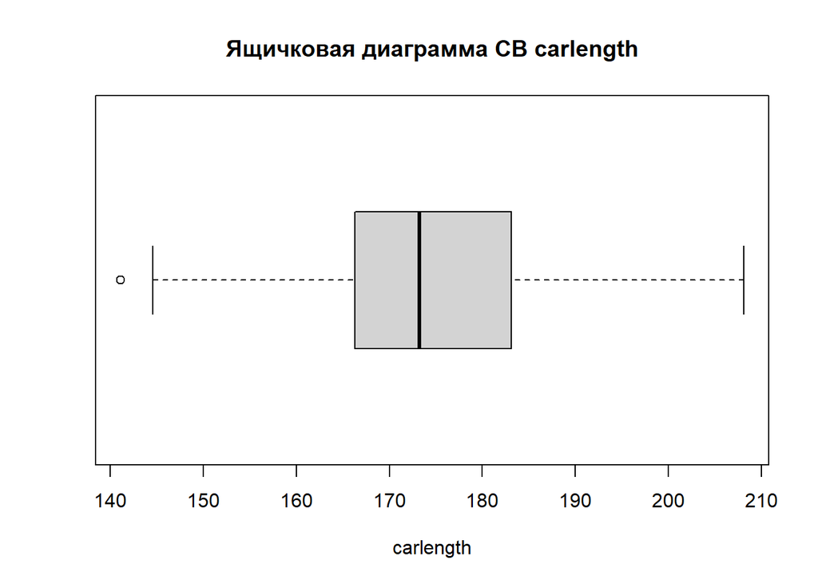

```r
boxplot(df$carlength, horizontal = TRUE, xlab = 'carlength', main = 'Ящичковая диаграмма СВ carlength')
```

На графике мы видим тот самый один выброс, выходящий за интервалы по правилу 1,5IQR. Его значение мы нашли ранее. Медиана находится ближе к значению первого квартиля (смещена влево в прямоугольнике, показывающем межквартильный диапазон).

*Проведем тест Граббса для данной СВ:*

Для проверки используем гипотезу $H_0$ о том, что одно максимальное или минимальное наблюдение в выборке является типичным наблюдением:

```r
grubbs.test(df$carlength)
```

```
##
##  Grubbs test for one outlier
##
## data:  df$carlength
## G = 2.75999, U = 0.96248, p-value = 0.5521
## alternative hypothesis: highest value 208.1 is an outlier
```

*P-value = 0,5521 > 0,05*

Следовательно, нулевая гипотеза **не отвергается**. Мы не можем сказать, что **максимальное значение** 208,1 является выбросом. Теперь произведем проверку минимального значения, для этого изменим аргумент **opposite** в функции на True:

```r
grubbs.test(df$carlength, opposite = TRUE)
```

```
##
##  Grubbs test for one outlier
##
## data:  df$carlength
## G = 2.67071, U = 0.96486, p-value = 0.7296
## alternative hypothesis: lowest value 141.1 is an outlier
```

Вновь значение p-value **больше** любого разумного уровня значимости, а соответственно нулевая гипотеза о том, что минимальное значение в выборке является типичным, **не отвергается**.

*Проведем тест Рознера для данной СВ:*

Он позволяет проверить больше одного наблюдения, скажем $k$, на резкое выделение.  
$H_0:$ $k$ наибольших наблюдений взяты из той же генеральной совокупности, что и $(n-k)$ первых наблюдений. Значение k выберем согласно количеству выбросов, полученных с помощью правила 1,5IQR:

```r
k1 = 2 # выставили данный параметр равным 2-м, несмотря на то, что по правилу 1,5IQR выброс только один - при k=1 тест Рознера проверяет выбросы у верхней границы

pander(rosnerTest(df$carlength, k = k1)$all.stats)
```

| i | Mean.i | SD.i | Value | Obs.Num | R.i+1 | lambda.i+1 | Outlier |
| --- | --- | --- | --- | --- | --- | --- | --- |
| 0 | 174 | 12.34 | 208.1 | 74 | 2.76 | 3.613 | FALSE |
| 1 | 173.9 | 12.13 | 141.1 | 19 | 2.702 | 3.611 | FALSE |

Таким образом, значение 141,1, которые мы получили с помощью правила 1,5IQR, не является выбросом согласно тесту Рознера.

**Важно отметить, что оба теста разработаны в предположении нормального распределения генеральной совокупности, из которой взята однородная выборка (от этого зависят критические значения, p-value и т.д.), поэтому в будущем необходимо проверить соответствуют ли наши случайные величины нормальному распределению.**

Теперь произведем те же расчеты для признака **`carwidth`**

*Расчет межквартильной разницы СВ:*

```r
pander(paste('Межквартильный размах: IQR = Q3 - Q1 = ', round(IQR(df$carwidth), 3)))
```

Межквартильный размах: IQR = Q3 - Q1 = 2.8

*Найдем значения, выходящие за пределы 1,5IQR:*

```r
carwidth_sorted <- sort(df$carwidth)
out_of_1.5IQR2 <- boxplot.stats(df$carwidth, coef = 1.5)$out
out_of_1.5IQR2
```

```
## [1] 71.4 71.4 71.4 71.7 71.7 71.7 72.0 72.3
```

Мы получили 8 выбросов.

```r
out_of_1.5IQR_carwidth <- which(carwidth_sorted %in% out_of_1.5IQR2)
```

```r
out_of_3IQR2 <- boxplot.stats(df$carwidth, coef = 3)$out
out_of_3IQR2
```

```
## numeric(0)
```

Таким образом, жесткое правило выбросов не выявило.

*Правило 3-х сигм:*

```r
pander(paste('3σ = ', round(3*sd(df$carwidth), 3)))
```

3σ = 6.436

$$P(|x-65.908| < 6.436)= 0,9973$$

$$P(59,472 < x < 72,344)= 0,9973$$

Полученный интервал покрывает все значения переменной, таким образом, согласно правилу трех сигм выбросов нет.

*Построим ящичковую диаграмму для данной СВ:*

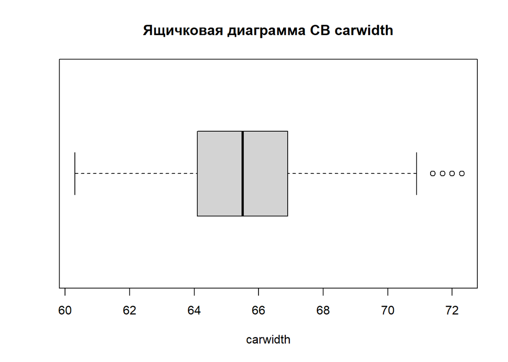

```r
boxplot(df$carwidth, horizontal = TRUE, xlab = 'carwidth', main = 'Ящичковая диаграмма СВ carwidth')
```

Заметим,что по графику видно только 4 выброса, но на деле – их 8 (нашли ранее).

Медиана равноудалена от значений квартилей (не смещена внутри прямоугольника, отражающего межквартильный диапазон).

*Проведем тест Граббса для данной СВ:*

```r
grubbs.test(df$carwidth)
```

```
##
##  Grubbs test for one outlier
##
## data:  df$carwidth
## G = 2.97976, U = 0.95626, p-value = 0.2683
## alternative hypothesis: highest value 72.3 is an outlier
```

Мы получили значение *p-value = 0,2683*. Поскольку это значение больше 0,05, то на заданном уровне значимости 5% мы принимаем нулевую гипотезу о том, что максимальное значение, равное 72,3, является типичным наблюдением.

```r
grubbs.test(df$carwidth, opposite = TRUE)
```

```
##
##  Grubbs test for one outlier
##
## data:  df$carwidth
## G = 2.61411, U = 0.96634, p-value = 0.8669
## alternative hypothesis: lowest value 60.3 is an outlier
```

Поскольку p-value вновь значительно больше 0,05, мы не можем отвергнуть нулевую гипотезу. У нас нет оснований полагать, что минимальное значение 60,3 является выбросом.

*Проведем тест Рознера для данной СВ:*

```r
k2 = length(out_of_1.5IQR_carwidth)
pander(rosnerTest(df$carwidth, k = k2)$all.stats)
```

| i | Mean.i | SD.i | Value | Obs.Num | R.i+1 | lambda.i+1 | Outlier |
| --- | --- | --- | --- | --- | --- | --- | --- |
| 0 | 65.91 | 2.145 | 72.3 | 130 | 2.98 | 3.613 | FALSE |
| 1 | 65.88 | 2.103 | 72 | 75 | 2.912 | 3.611 | FALSE |
| 2 | 65.85 | 2.063 | 71.7 | 71 | 2.837 | 3.61 | FALSE |
| 3 | 65.82 | 2.027 | 71.7 | 72 | 2.903 | 3.609 | FALSE |
| 4 | 65.79 | 1.989 | 71.7 | 74 | 2.973 | 3.607 | FALSE |
| 5 | 65.76 | 1.949 | 71.4 | 7 | 2.895 | 3.606 | FALSE |
| 6 | 65.73 | 1.912 | 71.4 | 8 | 2.966 | 3.604 | FALSE |
| 7 | 65.7 | 1.873 | 71.4 | 9 | 3.042 | 3.603 | FALSE |

Мы получили, что ни одно из восьми значений, полученных нами с помощью правила 1,5IQR, не является выбросом.

В 1-й категории осталось рассмотреть только переменную **`carheight:`**

*Расчет межквартильной разницы СВ:*

```r
pander(paste('Межквартильный размах: IQR = Q3 - Q1 = ', round(IQR(df$carheight), 3)))
```

Межквартильный размах: IQR = Q3 - Q1 = 3.5

*Найдем значения, выходящие за пределы 1,5IQR:*

```r
carheight_sorted <- sort(df$carheight)
out_of_1.5IQR3 <- boxplot.stats(df$carheight, coef = 1.5)$out
out_of_1.5IQR3
```

```
## numeric(0)
```

Выбросов нет. Проверять методом 3IQR смысла тоже тогда нет.

*Правило 3-х сигм:*

```r
paste('3σ = ', round(3*sd(df$carheight), 3))
```

```
## [1] "3σ =  7.331"
```

$$P(|x-53.725| < 7.331)= 0,9973$$

$$P( 46,394 < x < 61,056)= 0,9973$$

С вероятностью 0,9973 значения СВ **`carheight`** лежат в получившемся интервале. Так как в него попадают все значения нашей переменной, сделаем вывод, что согласно правилу 3-х сигм выбросов нет.

*Построим ящичковую диаграмму для данной СВ:*

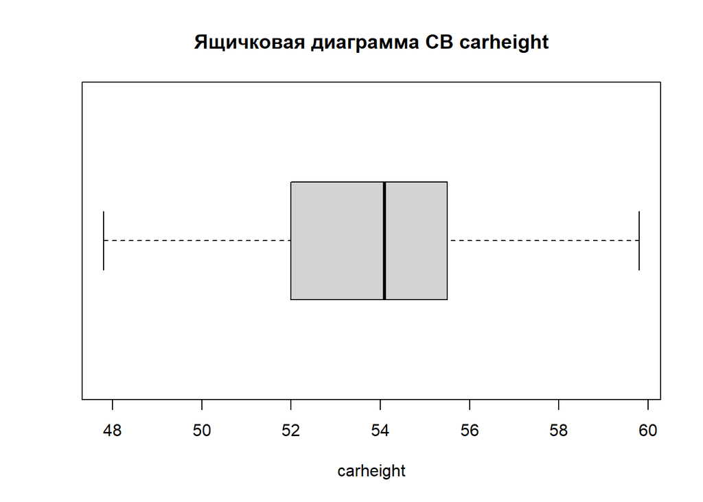

```r
boxplot(df$carheight, horizontal = TRUE, xlab = 'carheight', main = 'Ящичковая диаграмма СВ carheight')
```

На графике мы не видим выбросов по правилу 1,5IQR – это было отмечено выше. Медиана равна 54,1 и находится ближе к значению третьего квартиля (смещена вправо в прямоугольнике, показывающем межквартильный диапазон).

*Проведем тест Граббса для данной СВ:*

```r
grubbs.test(df$carheight)
```

```
##
##  Grubbs test for one outlier
##
## data:  df$carheight
## G = 2.48622, U = 0.96955, p-value = 1
## alternative hypothesis: highest value 59.8 is an outlier
```

Мы получили значение p-value = 1. Поскольку это значение больше 0,05, на данном уровне значимости мы принимаем нулевую гипотезу о том, что максимальное значение, равное 59,8, является типичным наблюдением.

```r
grubbs.test(df$carheight, opposite = TRUE)
```

```
##
##  Grubbs test for one outlier
##
## data:  df$carheight
## G = 2.42473, U = 0.97104, p-value = 1
## alternative hypothesis: lowest value 47.8 is an outlier
```

И снова p-value = 1. Следовательно, нулевая гипотеза о том, что минимальное значение в выборке является типичным, не отвергается.

### **Проверка соответствия эмпирического распределения нормальному закону (сarlength, carwidth, carheight)**

#### **Коэффициенты** **сarlength**

```r
pander(paste('Коэффициент асимметрии: As = ', round(Skew(df$carlength), 3)))
```

Коэффициент асимметрии: As = 0.154

```r
pander(paste('Коэффициент эксцесса: Ek = ', round(Kurt(df$carlength), 3)))
```

Коэффициент эксцесса: Ek = -0.138

*Интерпретация полученных значений:*

Коэффициент асимметрии положителен, по модулю не превышает 0.5, следовательно, имеет место слабая правосторонняя асимметрия.  
Коэффициент эксцесса отрицателен, что свидетельствует о плосковершинности распределения. Это **противоречит гипотезе о нормальном распределении.**

#### **Коэффициенты carwidth**

```r
pander(paste('Коэффициент асимметрии: As = ', round(Skew(df$carwidth), 3)))
```

Коэффициент асимметрии: As = 0.891

```r
pander(paste('Коэффициент эксцесса: Ek = ', round(Kurt(df$carwidth), 3)))
```

Коэффициент эксцесса: Ek = 0.621

*Интерпретация полученных значений:*

Коэффициент асимметрии положителен, по модулю превышает 0.5, следовательно, имеет место сильная правосторонняя асимметрия. Коэффициент эксцесса положителен, что свидетельствует об островершинности распределения относительно нормального. Это, безусловно, **противоречит гипотезе о нормальном распределении**.

#### **Коэффициенты** **carheigth**

```r
pander(paste('Коэффициент асимметрии: As = ', round(Skew(df$carheight), 3)))
```

Коэффициент асимметрии: As = 0.062

```r
pander(paste('Коэффициент эксцесса: Ek = ', round(Kurt(df$carheight), 3)))
```

Коэффициент эксцесса: Ek = -0.487

*Интерпретация полученных значений:*

Коэффициент асимметрии вновь положителен, но по модулю не превышает 0.5, следовательно, имеет место слабая правосторонняя асимметрия. Коэффициент эксцесса отрицателен, что свидетельствует о плосковершинности распределения относительно нормального, что также **противоречит гипотезе о нормальном распределении.**

### **Построим гистограммы распределения**

#### **Graph for carlength**

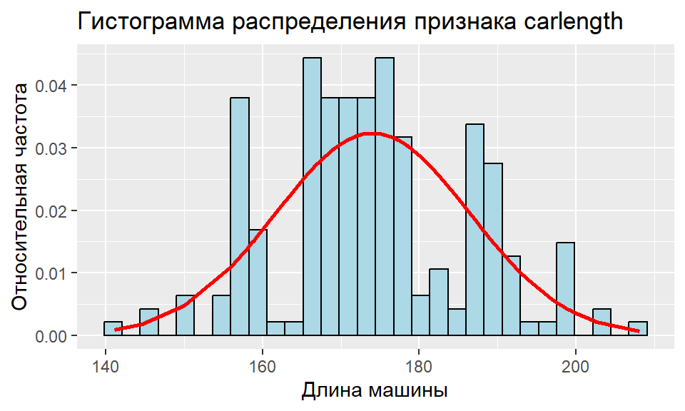

```r
ggplot(df, aes(x = df$carlength)) + labs(title = 'Гистограмма распределения признака carlength') +
  geom_histogram(aes(y=..density..),
                 color = "black", fill = "lightblue") +
  geom_line(aes(x = df$carlength, y = dnorm(df$carlength, mean = mean(df$carlength),
                                            sd = sd(df$carlength))), lwd = 1, col = 'red') +
  ylab("Относительная частота") +
  xlab("Длина машины")
```

График распределения переменной **`carlength`** не соответствует графику плотности нормального распределения. Её распределение хоть и близко к симметричному, но является бимодальным, что противоречит гипотезе о нормальном распределении.

#### **Graph for carwidth**

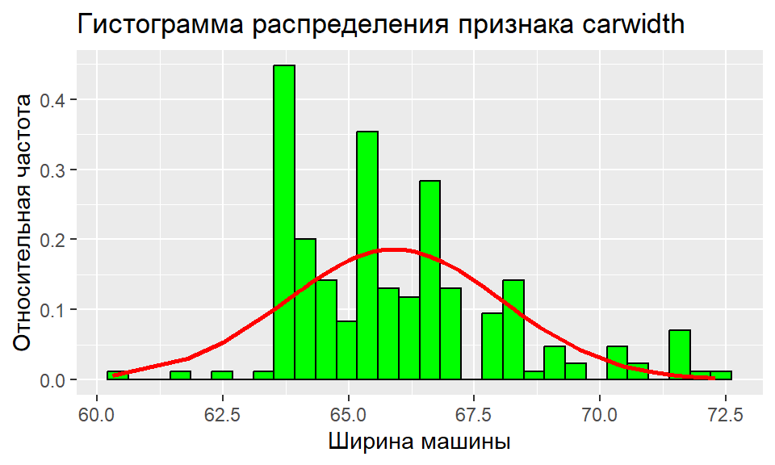

```r
ggplot(df, aes(x = df$carwidth)) + labs(title = 'Гистограмма распределения признака carwidth') +
  geom_histogram(aes(y=..density..),
                 color = "black", fill = "green") +
  geom_line(aes(x = df$carwidth, y = dnorm(df$carwidth,
                                           mean = mean(df$carwidth),
          sd = sd(df$carwidth))),lwd = 1, col = 'red') +
  ylab("Относительная частота") +
  xlab("Ширина машины")
```

По графику видно, что наша переменная имеет значительный коэффициент эксцесса, мода сильно смещена влево относительно медианы и средней.

#### **Graph for carheigth**

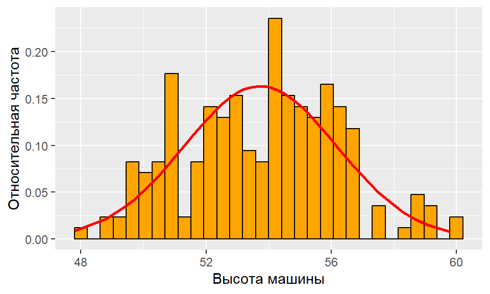

```r
ggplot(df, aes(x = df$carheight)) +
  geom_histogram(aes(y=..density..),
                 color = "black", fill = "orange") +
  geom_line(aes(x = df$carheight, y = dnorm(df$carheight,
    mean = mean(df$carheight), sd = sd(df$carheight))),
    lwd = 1, col = 'red') +
  ylab("Относительная частота") +
  xlab("Высота машины")
```

График распределения переменной **не соответствует** графику плотности нормального распределения. Но заметим, что коэффициент асимметрии незначителен.

### **Построим графики *dotplot***

#### **Dotplot for carlength**

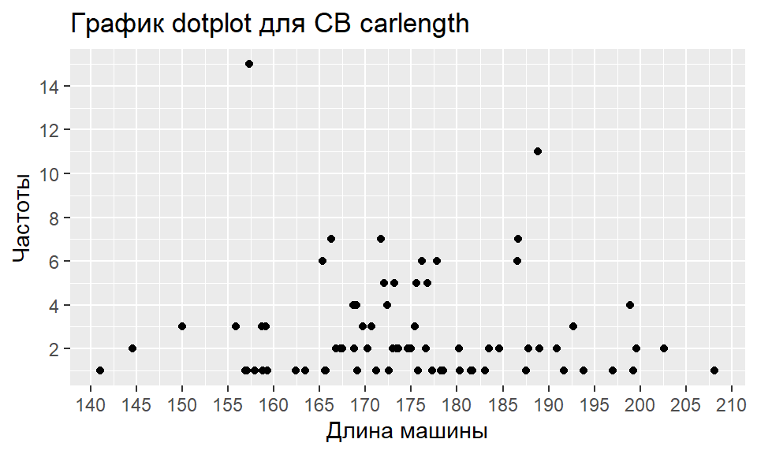

```r
carlength_dot <- ggplot(data = dotplot1) + geom_point(mapping = aes(x = Var1, Freq)) + scale_x_continuous(breaks = seq(0, 220, 5)) + scale_y_continuous(breaks = seq(0, 20, 2)) + labs(title = 'График dotplot для СВ carlength') + ylab("Частоты") +
  xlab("Длина машины")
carlength_dot
```

По графику dotplot переменной **`carlength`** (длина машины) видно, что наше распределение близко к нормальному, т.к. в центре графика у нас скопилось множество точек. Эти точки находятся невысоко, но встречаются очень часто, что свидетельствует о том, что в диапазоне 160-185 находится большая часть наблюдений.

Также можно увидеть модальное значение = 157,3 (встречается 15 раз). Это значение смещено от медианного влево и может способствовать появлению правосторонней асимметрии у графика плотности переменной **`carlength`**, однако эта асимметрия может быть скомпенсирована значениями: 188,8 (встречается 11 раз), 186,6 (встречается 6 раз), 186,7 (встречается 7 раз), находящимися справа от центрального диапазона (160-185).

#### **Dotplot for carwidth**

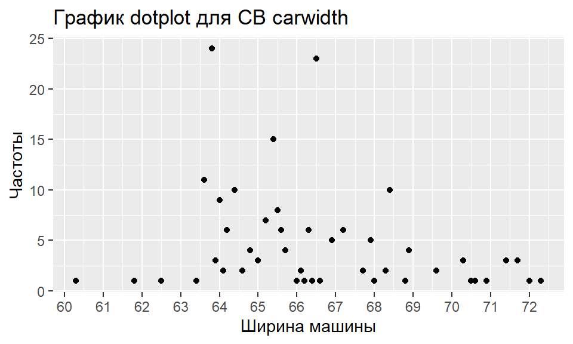

```r
carwidth_dot <- ggplot(data = dotplot2) + geom_point(mapping = aes(x = Var1, Freq)) + scale_x_continuous(breaks = seq(0, 100, 1)) + labs(title = 'График dotplot для СВ carwidth') +
  ylab("Частоты") +
  xlab("Ширина машины")
carwidth_dot
```

#### **Dotplot for carheight**

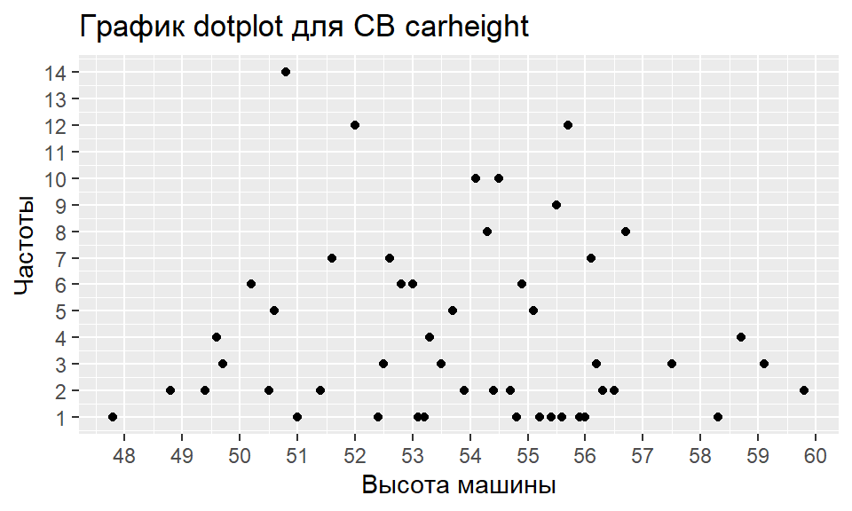

```r
carheight_dot <- ggplot(data = dotplot3) + geom_point(mapping = aes(x = Var1, Freq)) + scale_x_continuous(breaks = seq(0, 60, 1)) + scale_y_continuous(breaks = seq(0, 20, 1)) + labs(title = 'График dotplot для СВ carheight') +
  ylab("Частоты") +
  xlab("Высота машины")
carheight_dot
```

График dotplot переменная **`carheight`** (высота машины) достаточно симметричный и возможно carheight распределена нормально(проверим данную гипотезу чуть позже). Модальное значение 50,8 (встречается 14 раз). Большинство предпочитает автомобили с средней высотой, находя ее оптимальной.

### **Проверка гипотезы о нормальном распределении совокупности с использованием статистического критерия (критерий Пирсона, Колмогорова)**

Для проверки соответствия эмпирического распределения некоторому теоретическому используют критерии согласия. Нас интересует проверка следующей гипотезы:

$$H_0 : \text{ выборка взята из генеральной совокупности с нормальным
распределением }$$

#### **Tests for carlength**

*Критерий согласия Пирсона:*

```r
pander(PearsonTest(df$carlength))
```

Pearson chi-square normality test: `df$carlength`

| Test statistic | P value |
| --- | --- |
| 94.78 | 4.708e-14 * * * |

*Критерий Шапиро-Уилка:*

```r
pander(shapiro.test(df$carlength))
```

Shapiro-Wilk normality test: `df$carlength`

| Test statistic | P value |
| --- | --- |
| 0.9821 | 0.01036 * |

*Тест Колмогорова-Смирнова:*

```r
pander(ks.test(df$carlength, 'pnorm', mean(df$carlength), sd(df$carlength)))
```

Asymptotic one-sample Kolmogorov-Smirnov test: `df$carlength`

| Test statistic | P value | Alternative hypothesis |
| --- | --- | --- |
| 0.08787 | 0.08434 | two-sided |

#### **Tests for carwidth**

*Критерий согласия Пирсона:*

```r
pander(PearsonTest(df$carwidth))
```

Pearson chi-square normality test: `df$carwidth`

| Test statistic | P value |
| --- | --- |
| 133.9 | 1.14e-21 * * * |

Нулевая гипотеза отвергается с вероятностью ошибки 0,05. Следовательно, мы не можем утверждать, что выборка взята из генеральной совокупности с нормальным распределением, такой же вывод мы сделали исходя из графика.

*Критерий Шапиро-Уилка:*

```r
pander(shapiro.test(df$carwidth))
```

Shapiro-Wilk normality test: `df$carwidth`

| Test statistic | P value |
| --- | --- |
| 0.9211 | 5.013e-09 * * * |

Здесь также получаем p-value значительно меньше 0,05, следовательно, по критерию Шапиро-Уилка нулевая гипотеза о нормальности распределения генеральной совокупности случайной величины **`carwidth`** отвергается с вероятностью ошибки 0,05.

*Тест Колмогорова-Смирнова:*

```r
pander(ks.test(df$carwidth, 'pnorm', mean(df$carwidth), sd(df$carwidth)))
```

Asymptotic one-sample Kolmogorov-Smirnov test: `df$carwidth`

| Test statistic | P value | Alternative hypothesis |
| --- | --- | --- |
| 0.1327 | 0.001461 * * | two-sided |

P-value маленькое, т.е. нулевая гипотеза о нормальности распределения отвергается с вероятностью ошибки 0,05.

Таким образом, на основе результатов трех тестов мы можем сказать, что случайная величина **`carwidth`** не подчиняется нормальному закону распределения.

#### **Test for carheight**

*Критерий согласия Пирсона:*

```r
pander(PearsonTest(df$carheight))
```

Pearson chi-square normality test: `df$carheight`

| Test statistic | P value |
| --- | --- |
| 53.98 | 1.295e-06 * * * |

P-value очень маленькое, меньше любого разумного уровня значимости. Следовательно, нулевая гипотеза о нормальности распределения отвергается с вероятностью ошибки 0,05.

*Критерий Шапиро-Уилка:*

```r
pander(shapiro.test(df$carheight))
```

Shapiro-Wilk normality test: `df$carheight`

| Test statistic | P value |
| --- | --- |
| 0.9842 | 0.02167 * |

P-value принимает маленькое значение. Следовательно, нулевая гипотеза о нормальности распределения также отвергается с вероятностью ошибки 0,05.

*Тест Колмогорова-Смирнова:*

```r
pander(ks.test(df$carheight, 'pnorm', mean(df$carheight), sd(df$carheight)))
```

Asymptotic one-sample Kolmogorov-Smirnov test: `df$carheight`

| Test statistic | P value | Alternative hypothesis |
| --- | --- | --- |
| 0.07459 | 0.2041 | two-sided |

P-value = 0,2041. Следовательно, с вероятностью ошибки 0,05 нулевая гипотеза о нормальности распределения **не отвергается**.

Таким образом, на основе результатов двух критериев (Пирсона и Шапиро-Уилка) мы можем утверждать, что случайная величина **`carheight`** не подчиняется нормальному закону распределения.

### **Основные характеристики (enginesize, horsepower, peakrpm)**

Продолжим предварительный анализ переменных. Рассмотрим следующую категорию признаков *“Двигатель”*:

#### **Анализ enginesize**

*Характеристики положения СВ:*

```r
pander(paste('Среднее: ', round(mean(df$enginesize), 3)))
```

Среднее: 126.907

```r
pander(paste('Медиана: ', median(df$enginesize)))
```

Медиана: 120

```r
pander(paste('Мода: ', Mode(df$enginesize)))
```

*Мода: 92* and *Мода: 122*

*Характеристики разброса СВ:*

```r
ch_var4 <- data.frame('Статистика' =
                       c('Min', 'Max', 'Размах: R',
                         'Дисперсия', 'Std dev',
                         'IQR', 'Coef var, %'),
                     'Значение' = c(range(df$enginesize)[1],
                                    range(df$enginesize)[2],
                                    round(range(df$enginesize)[2] - range(df$enginesize)[1], 3),
                     round(var(df$enginesize), 3),
                     round(sd(df$enginesize), 3),
                     IQR(df$enginesize),
                     round(CoefVar(df$enginesize)*100, 2)))

pander(ch_var4)
```

| Статистика | Значение |
| --- | --- |
| Min | 61 |
| Max | 326 |
| Размах: R | 265 |
| Дисперсия | 1734 |
| Std dev | 41.64 |
| IQR | 44 |
| Coef var, % | 32.81 |

Значение коэффициента вариации не превышает 33%. Это говорит нам об однородности переменной “объем двигателя”.

*Ранговые характеристики СВ:*

```r
pander(summary(df$enginesize))
```

| Min. | 1st Qu. | Median | Mean | 3rd Qu. | Max. |
| --- | --- | --- | --- | --- | --- |
| 61 | 97 | 120 | 126.9 | 141 | 326 |

```r
pander(quantile(df$enginesize))
```

| 0% | 25% | 50% | 75% | 100% |
| --- | --- | --- | --- | --- |
| 61 | 97 | 120 | 141 | 326 |

Для случайной величины “объем двигателя” мы получили: Q1 = 97; Q3 = 141. Следовательно, 25% выборки принимает значения меньше 97; 25% выборки принимают значения больше 141.

```r
pander(quantile(df$enginesize, probs = seq(0, 1, 0.1)))
```

| 0% | 10% | 20% | 30% | 40% | 50% | 60% | 70% | 80% | 90% | 100% |
| --- | --- | --- | --- | --- | --- | --- | --- | --- | --- | --- |
| 61 | 91 | 97 | 98 | 109 | 120 | 122 | 136 | 152 | 181 | 326 |

Для этой случайной величины мы также нашли децили. Здесь 30% значений выборки меньше 98. Медиана равна 120, то есть половины значений выборки принимают значения меньше 120. Минимальное значение - 61; Максимальное - 326.

#### **Анализ horsepower**

*Характеристики положения СВ:*

```r
pander(paste('Среднее: ', round(mean(df$horsepower), 3)))
```

Среднее: 104.117

```r
pander(paste('Медиана: ', median(df$horsepower)))
```

Медиана: 95

```r
pander(paste('Мода: ', Mode(df$horsepower)))
```

Мода: 68

Необходимо заметить, что полученные значения среднего, медианы и моды не равны, значения существенно отличаются друг от друга. Это позволяет нам сделать предположение о том, что распределение переменной **`horsepower`**(лошадиные силы (в киловаттах)) не соответствует нормальному закону

*Характеристики разброса СВ:*

```r
ch_var5 <- data.frame('Статистика' =
                       c('Min', 'Max', 'Размах: R',
                         'Дисперсия', 'Std dev',
                         'IQR', 'Coef var, %'),
                     'Значение' = c(range(df$horsepower)[1],
                                    range(df$horsepower)[2],
                                    round(range(df$horsepower)[2] - range(df$horsepower)[1], 3),
                     round(var(df$horsepower), 3),
                     round(sd(df$horsepower), 3),
                     IQR(df$horsepower),
                     round(CoefVar(df$horsepower)*100, 2)))

pander(ch_var5)
```

| Статистика | Значение |
| --- | --- |
| Min | 48 |
| Max | 288 |
| Размах: R | 240 |
| Дисперсия | 1564 |
| Std dev | 39.54 |
| IQR | 46 |
| Coef var, % | 37.98 |

Значение коэффициента вариации показывает степень изменчивости по отношению к среднему показателю выборки. У нас оно превышает 33%, что может свидетельствовать об неоднородности переменной `horsepower`(лошадиные силы (в киловаттах)). Поэтому средние для неоднородной совокупности – не значимы и не характеризуют совокупность из-за значительного разброса значений признака в данной совокупности.

*Ранговые характеристики СВ:*

```r
pander(summary(df$horsepower))
```

| Min. | 1st Qu. | Median | Mean | 3rd Qu. | Max. |
| --- | --- | --- | --- | --- | --- |
| 48 | 70 | 95 | 104.1 | 116 | 288 |

```r
pander(quantile(df$horsepower))
```

| 0% | 25% | 50% | 75% | 100% |
| --- | --- | --- | --- | --- |
| 48 | 70 | 95 | 116 | 288 |

Для случайной величины `horsepower`(лошадиные силы (в киловаттах)) мы получили: Q1 = 70; Q3 = 116. Следовательно, 25% выборки принимает значения меньше 70; 25% выборки принимают значения больше 116. Медиана = 95 правее и левее данного значения находится по 50% выборки. Медиана меньше среднего значения по выборке, что может говорить о правосторонней асимметрии.

```r
pander(quantile(df$horsepower, probs = seq(0, 1, 0.1)))
```

| 0% | 10% | 20% | 30% | 40% | 50% | 60% | 70% | 80% | 90% | 100% |
| --- | --- | --- | --- | --- | --- | --- | --- | --- | --- | --- |
| 48 | 68 | 69 | 76 | 87.2 | 95 | 102 | 114 | 134.2 | 160 | 288 |

Аналогичные выводы можно сделать и по децилям. Можно заметить, что разница между медианной и минимальным значением значительно меньше, чем разница между максимальным значением и медианой, что может свидетельствовать о сильной правосторонней асимметрии.

#### **Анализ peakrpm**

*Характеристики положения СВ:*

```r
pander(paste('Среднее: ', round(mean(df$peakrpm), 3)))
```

Среднее: 5125.122

```r
pander(paste('Медиана: ', median(df$peakrpm)))
```

Медиана: 5200

```r
pander(paste('Мода: ', Mode(df$peakrpm)))
```

Мода: 5500

Посчитанные значения среднего, моды и медианы отличаются друг от друга. Данный факт свидетельствует о том, что СВ **`peakrpm,`** вероятно, **не подчиняется нормальному распределению**.

*Характеристики разброса СВ:*

```r
ch_var6 <- data.frame('Статистика' =
                       c('Min', 'Max', 'Размах: R',
                         'Дисперсия', 'Std dev',
                         'IQR', 'Coef var, %'),
                     'Значение' = c(range(df$peakrpm)[1],
                                    range(df$peakrpm)[2],
                                    round(range(df$peakrpm)[2] - range(df$peakrpm)[1], 3),
                     round(var(df$peakrpm), 3),
                     round(sd(df$peakrpm), 3),
                     IQR(df$peakrpm),
                     round(CoefVar(df$peakrpm)*100, 2)))

pander(ch_var6)
```

| Статистика | Значение |
| --- | --- |
| Min | 4150 |
| Max | 6600 |
| Размах: R | 2450 |
| Дисперсия | 227515 |
| Std dev | 477 |
| IQR | 700 |
| Coef var, % | 9.31 |

```r
pander(summary(df$peakrpm))
```

| Min. | 1st Qu. | Median | Mean | 3rd Qu. | Max. |
| --- | --- | --- | --- | --- | --- |
| 4150 | 4800 | 5200 | 5125 | 5500 | 6600 |

```r
pander(quantile(df$peakrpm))
```

| 0% | 25% | 50% | 75% | 100% |
| --- | --- | --- | --- | --- |
| 4150 | 4800 | 5200 | 5500 | 6600 |

Так как Q1 = 4800, то 25% выборки лежит “левее” данного значения, а еще четверть – правее Q3 = 5500. Медиана равна 5200 и немного больше среднего значения по выборке, что может говорить о левосторонней асимметрии.

```r
pander(quantile(df$peakrpm, probs = seq(0, 1, 0.1)))
```

| 0% | 10% | 20% | 30% | 40% | 50% | 60% | 70% | 80% | 90% | 100% |
| --- | --- | --- | --- | --- | --- | --- | --- | --- | --- | --- |
| 4150 | 4500 | 4800 | 4800 | 5000 | 5200 | 5200 | 5400 | 5500 | 5780 | 6600 |

### **Диагностика выбросов (enginesize, horsepower, peakrpm)**

#### **Анализ enginesize**

*Расчет межквартильной разницы СВ:*

```r
pander(paste('Межквартильный размах: IQR = Q3 - Q1 = ', round(IQR(df$enginesize), 3)))
```

Межквартильный размах: IQR = Q3 - Q1 = 44

*Найдем значения, выходящие за пределы 1,5IQR:*

```r
carengine_sorted <- sort(df$enginesize)
out_of_1.5IQR4 <- boxplot.stats(df$enginesize, coef = 1.5)$out
out_of_1.5IQR4
```

```
##  [1] 209 209 209 258 258 326 234 234 308 304
```

Получаем выбросы - 209 (х3), 258 (х2) 326, 234 (х2), 308, 304.

*Применим правило 3IQR:*

```r
out_of_3IQR4 <- boxplot.stats(df$enginesize, coef = 3)$out
out_of_3IQR4
```

```
## [1] 326 308 304
```

Выбросы по результатам жесткого правила: 326, 308, 304.

*Правило 3-х сигм:*

```r
pander(paste('3σ = ', round(3*sd(df$enginesize), 3)))
```

3σ = 124.928

$$P(|x-126.907| < 124.928)= 0,9973$$

$$P( 1,979 < x < 251,835)= 0,9973$$

С вероятностью 0,9973 значения величины “объем двигателя” лежат в интервале от 1,979 до 251,835. Следовательно, согласно правилу трех сигм выбросы также присутствуют.

*Построим ящичковую диаграмму для данной СВ:*

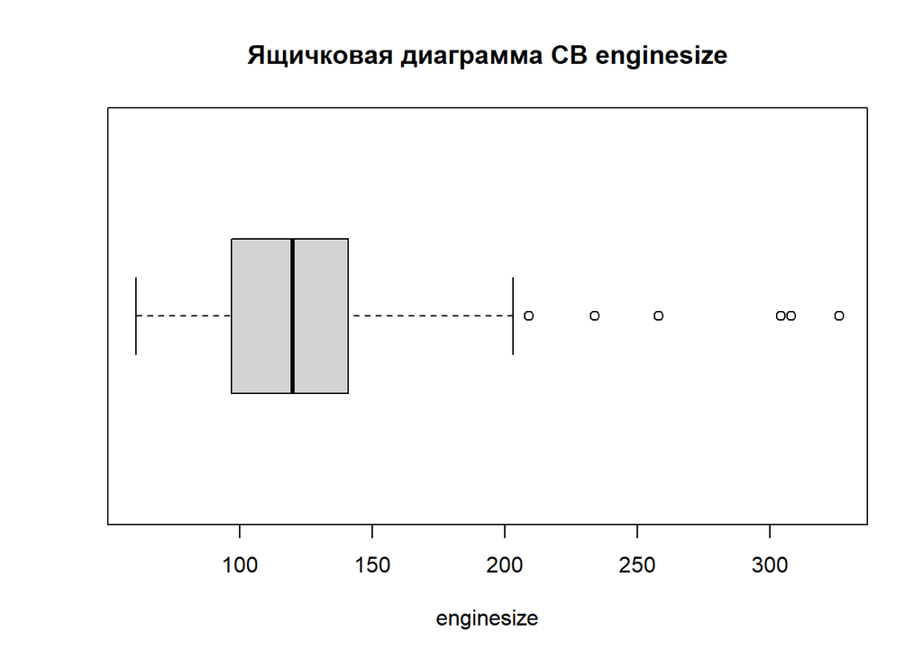

```r
boxplot(df$enginesize, horizontal = TRUE, xlab = 'enginesize', main = 'Ящичковая диаграмма СВ enginesize')
```

На графике мы видим выбросы, выходящие за пределы правила 1,5IQR. Их значения мы нашли выше.

*Проведем тест Граббса для данной СВ:*

```r
grubbs.test(df$enginesize)
```

```
##
##  Grubbs test for one outlier
##
## data:  df$enginesize
## G = 4.7810, U = 0.8874, p-value = 8.944e-05
## alternative hypothesis: highest value 326 is an outlier
```

P-value = 8.944e-05 < 0,05. Следовательно, нулевая гипотеза отвергается. Мы можем сказать, что максимальное значение является выбросом.

```r
grubbs.test(df$enginesize, opposite = TRUE)
```

```
##
##  Grubbs test for one outlier
##
## data:  df$enginesize
## G = 1.58269, U = 0.98766, p-value = 1
## alternative hypothesis: lowest value 61 is an outlier
```

В этом случае также p-value = 1 > 0,05. Нулевая гипотеза о том, что минимальное значение в выборке является типичным, не отвергается.

#### **Анализ horsepower**

*Расчет межквартильной разницы СВ:*

```r
pander(paste('Межквартильный размах: IQR = Q3 - Q1 = ', round(IQR(df$horsepower), 3)))
```

Межквартильный размах: IQR = Q3 - Q1 = 46

*Найдем значения, выходящие за пределы 1,5IQR:*

```r
carhp_sorted <- sort(df$horsepower)
out_of_1.5IQR5 <- boxplot.stats(df$horsepower, coef = 1.5)$out
out_of_1.5IQR5
```

```
## [1] 262 200 207 207 207 288
```

Мы получили 6 выбросов. Они принимают значение: 200 (1 шт.), 207 (3 шт.), 262 (1 шт.), 288 (1 шт.)

*Применим правило 3IQR:*

```r
out_of_3IQR5 <- boxplot.stats(df$horsepower, coef = 3)$out
out_of_3IQR5
```

```
## [1] 262 288
```

По правилу 3IQR у нас только 2 выброса сверху: 262 и 288.

*Правило 3-х сигм:*

```r
pander(paste('3σ = ', round(3*sd(df$horsepower), 3)))
```

3σ = 118.633

$$P(|x-104,117| < 118.633)= 0,9973$$

$$P(-14,516 < x < 222,750)= 0,9973$$

С вероятностью 0,9973 значения величины `horsepower` (лошадиные силы) лежат в интервале от -14,516 до 222,75. Эта переменная принимает только положительные значения, максимальное значение равно 222,75. Следовательно, согласно правилу трех сигм у нас 2 выброса: 262 и 288.

*Построим ящичковую диаграмму для данной СВ:*

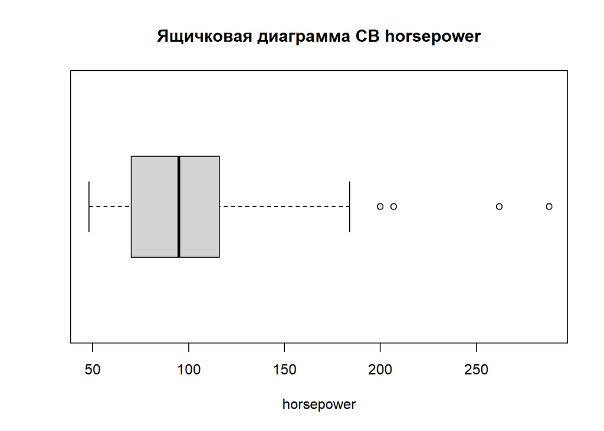

```r
boxplot(df$horsepower, horizontal = TRUE, xlab = 'horsepower', main = 'Ящичковая диаграмма СВ horsepower')
```

На графике ряд значений выходят за пределы правила 1.5IQR, то есть являются выбросами (выше мы получили, что их 6, три из них равны). Медиана равна 95 и находится ближе к значению третьего квартиля (смещена вправо в прямоугольнике, показывающем межквартильный диапазон). Первый квартиль значение 70, третий - 116.

*Проведем тест Граббса для данной СВ:*

```r
grubbs.test(df$horsepower)
```

```
##
##  Grubbs test for one outlier
##
## data:  df$horsepower
## G = 4.65006, U = 0.89348, p-value = 0.0001836
## alternative hypothesis: highest value 288 is an outlier
```

Мы получили значение p-value = 0,00018. Поскольку это значение меньше 0,05, мы отвергаем нулевую гипотезу и делаем вывод о том, что максимальное значение 288 является выбросом.

```r
grubbs.test(df$horsepower, opposite = TRUE)
```

```
##
##  Grubbs test for one outlier
##
## data:  df$horsepower
## G = 1.41910, U = 0.99008, p-value = 1
## alternative hypothesis: lowest value 48 is an outlier
```

P-value **= 1**. Поскольку это значение не меньше 0,05, мы не можем отвергнуть нулевую гипотезу. У нас нет достаточных доказательств, чтобы сказать, что минимальное значение 48 является выбросом. Наши выводы по диагностике выбросов с использованием других правил подтвердились.